# Tidytuesday Avatar

Maria Dermit

2020-08-12

# Titytuesday Avatar 2020-08-12

```r
library(tidytuesdayR)
library(tidyverse)
library(tidymodels)
library(stringr)
```

### Getting data

```r
avatar <- readr::read_csv('https://raw.githubusercontent.com/rfordatascience/tidytuesday/master/data/2020/2020-08-11/avatar.csv')
scene_description <- readr::read_csv('https://raw.githubusercontent.com/rfordatascience/tidytuesday/master/data/2020/2020-08-11/scene_description.csv')
```

### Data exploration

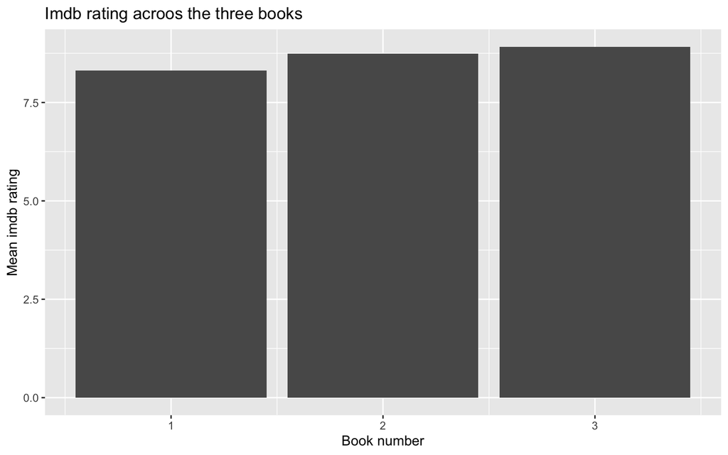

```r
avatar_summary_chapter<-
  avatar %>% group_by(book_num,chapter_num) %>%
  summarize(mean_rating = mean(imdb_rating, na.rm = TRUE)) %>%
  as_tibble() %>%
  mutate_if(is.character,as.factor)

avatar_summary_chapter %>% group_by(book_num) %>%
  summarize(mean_rating = mean(mean_rating, na.rm = TRUE))  %>%
  ggplot(aes(book_num,mean_rating)) +
  geom_bar(stat='identity')+
  theme(legend.position='none')+
  labs(title = "Imdb rating acroos the three books",
  y = "Mean imdb rating", x = "Book number")
```

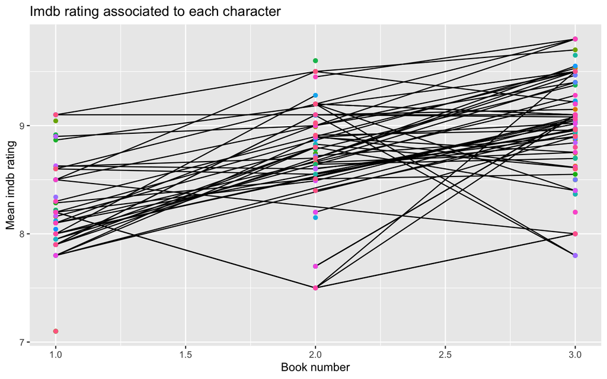

```r
avatar_summary_character<-avatar %>% group_by(character,book_num) %>%
  summarize(mean_rating = mean(imdb_rating)) %>%
  as_tibble() %>%
  mutate_if(is.character,as.factor)

avatar_summary_character %>%
ggplot(aes(book_num,mean_rating,group=character))+
  geom_line(aes(group = character)) +
  geom_point(aes(color=character))+
  theme(legend.position='none')+
   labs(title = "Imdb rating associated to each character",
  y = "Mean imdb rating", x = "Book number")
```

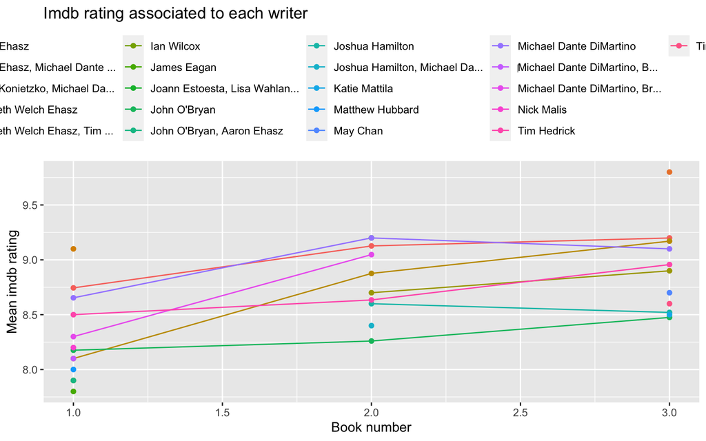

```r
avatar_summary_writer<-avatar %>% group_by(writer,book_num) %>%
  summarize(mean_rating = mean(imdb_rating,na.rm=TRUE)) %>%
  as_tibble()
 # mutate_if(is.character,as.factor)

avatar_summary_writer$writer <-avatar_summary_writer$writer %>%  str_trunc(.,30,"right")
avatar_summary_writer<-avatar_summary_writer %>% mutate_if(is.character,as.factor)


avatar_summary_writer %>%
  ggplot(aes(book_num,mean_rating))+
  geom_line(aes(group = writer, color=writer)) +
  geom_point(aes( color=writer))+
  theme(legend.position='top')+
  labs(title = "Imdb rating associated to each writer",
  y = "Mean imdb rating", x = "Book number")
```

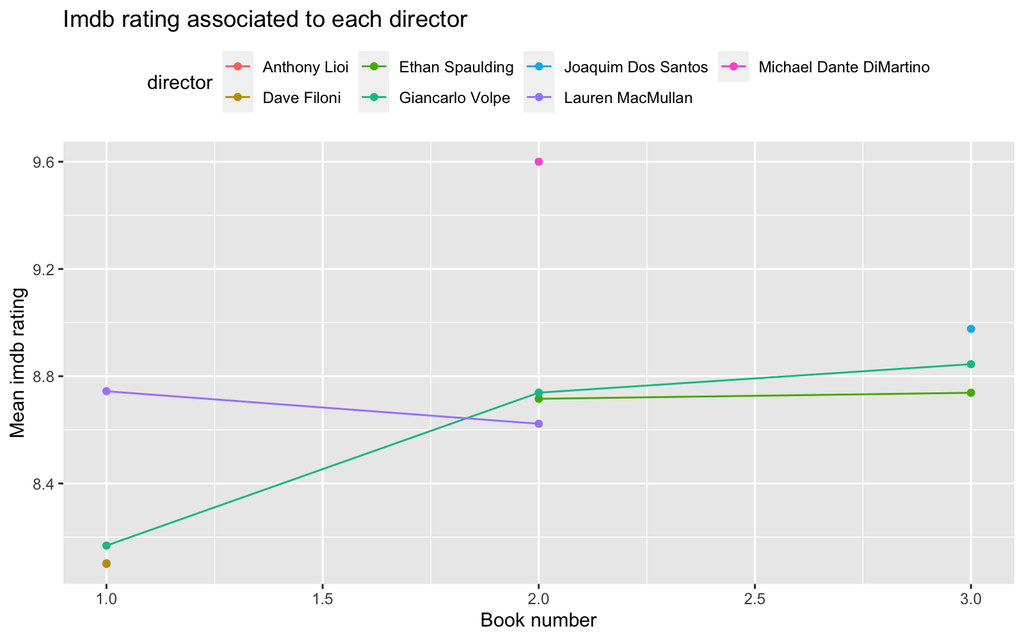

```r
avatar_summary_director<-avatar %>% group_by(director,book_num) %>%
  summarize(mean_rating = mean(imdb_rating,na.rm=TRUE)) %>%
  as_tibble() %>%
 mutate_if(is.character,as.factor)

avatar_summary_director %>%
  ggplot(aes(book_num,mean_rating))+
  geom_line(aes(group = director, color=director)) +
  geom_point(aes( color=director))+
  theme(legend.position='top')+
  labs(title = "Imdb rating associated to each director",
  y = "Mean imdb rating", x = "Book number")
```

[figure not shown]

```r
avatar_summary_director_writer<-avatar %>% group_by(writer,director,book_num) %>%
  summarize(mean_rating = mean(imdb_rating,na.rm=TRUE)) %>%
  as_tibble() %>%
  mutate(combination=paste(writer,director,sep="."))

avatar_summary_director_writer$combination <-avatar_summary_director_writer$combination %>%  str_trunc(.,30,"right")
avatar_summary_director_writer<-avatar_summary_director_writer %>% mutate_if(is.character,as.factor)

  #mutate_if(is.character,as.factor)

avatar_summary_director_writer %>%
  drop_na() %>%
  ggplot(aes(mean_rating,combination))+
    geom_bar(position="dodge", stat="identity")+
    theme(legend.position='top')+
  labs(title = "Imdb rating associated to each director",
  y = "Mean imdb rating", x = "Book number")
```

It looks like episodes associated to later books got a slightly better Imdb rating. Some characters tend to be associated with better Imdb rating. Also it seems that episodes based on chapters written by some authors get very different Imdb rating. For instance episodes based on Book 1 chapters written by some authors got low Imdb rating and those authors did not participate writting chapters in Book 2 and Book 3. It looks like some star author(s) were hired for the last book, and this chapter got highest Imdb rating. Finally, some directors that directed episodes based on Book 2 and 3 got pretty high rating, and it looks like those directors were hired for one season only.

Some writers may be writing more about popular characters and likewisely some episodes directed by some directors may have higher presence of some popular characters, which may be pushing higher Imdb rates these artist may eventually receive. Maybe a combination of best writers and directors gives the top rates.

Next question we have is what parameters are driving Imdb rating?

```r
avatar_simple<-avatar %>%
  select(character,book_num,chapter_num,writer,director,imdb_rating) %>%
  dplyr::mutate(book_num = replace_na(book_num, 0),
                chapter_num = replace_na(chapter_num, 0),
                imdb_rating= replace_na(imdb_rating, 0),
                character= replace_na(character, 0),
                ) %>%
  dplyr::filter(imdb_rating!=0) %>%
  mutate(imdb_rating = case_when(
    imdb_rating > 8.75 ~ "high",
      imdb_rating < 8.75 ~ "low")) %>% unique()%>%
    na.omit() %>%
    mutate_if(is.character, factor) %>%

  janitor::clean_names() %>%
  mutate(character = fct_lump(character,100))

avatar_simple %>% count(imdb_rating)
```

```
## # A tibble: 2 x 2
##   imdb_rating     n
##   <fct>       <int>
## 1 high          474
## 2 low           475
```

We can consider an Imdb rating as low if this is <8.75 and high if Imdb rating is >8.75

### Building models with recipes

```r
avatar_split <- initial_split(avatar_simple, strata = imdb_rating)
avatar_train <- training(avatar_split)
avatar_test <- testing(avatar_split)

avatar_rec <- recipe(imdb_rating ~ ., data = avatar_train) %>%
# update_role(id, new_role = "ID") %>%
  step_dummy(all_nominal(), -all_outcomes()) %>%
  step_zv(all_numeric()) %>%
  step_normalize(all_numeric())

avatar_prep <- avatar_rec %>%prep()
avatar_juiced <- juice(avatar_prep)

glm_spec <- logistic_reg() %>%
  set_engine("glm")

glm_fit <- glm_spec %>%
  fit(imdb_rating ~ ., data = avatar_juiced)

knn_spec <- nearest_neighbor() %>%
  set_engine("kknn") %>%
  set_mode("classification")

knn_fit <- knn_spec %>%
  fit(imdb_rating ~ ., data = avatar_juiced)

tree_spec <- decision_tree() %>%
  set_engine("rpart") %>%
  set_mode("classification")

tree_fit <- tree_spec %>%
  fit(imdb_rating ~ ., data = avatar_juiced)
```

### We can now evaluate the models with resampling

```r
set.seed(2020)
folds <- vfold_cv(avatar_train, strata = imdb_rating)
```

We can estimate the models metrics

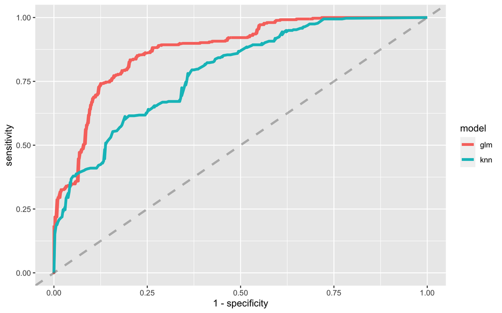

```r
set.seed(234)
glm_rs <- glm_spec %>%
  fit_resamples(
    avatar_rec,
    folds,
    metrics = metric_set(roc_auc, sens, spec),
    control = control_resamples(save_pred = TRUE)
  )

set.seed(234)
knn_rs <- knn_spec %>%
  fit_resamples(
    avatar_rec,
    folds,
    metrics = metric_set(roc_auc, sens, spec),
    control = control_resamples(save_pred = TRUE)
  )

set.seed(234)
tree_rs <- tree_spec %>%
  fit_resamples(
    avatar_rec,
    folds,
    metrics = metric_set(roc_auc, sens, spec),
    control = control_resamples(save_pred = TRUE)
  )

glm_rs %>%
  unnest(.predictions) %>%
  mutate(model = "glm") %>%
  bind_rows(knn_rs %>%
    unnest(.predictions) %>%
    mutate(model = "knn")) %>%
  group_by(model) %>%
  roc_curve(imdb_rating, .pred_high) %>%
  ggplot(aes(x = 1 - specificity, y = sensitivity, color = model)) +
  geom_line(size = 1.5) +
  geom_abline(
    lty = 2, alpha = 0.5,
    color = "gray50",
    size = 1.2
  )
```

Logistic regression model performs a bit better, so we can look at the parameters in detail.

```r
glm_fit %>%
  tidy() %>%
  arrange(-estimate) %>% slice(1:3,124:126)
```

```
## # A tibble: 6 x 5
##   term                                      estimate std.error statistic p.value
##   <chr>                                        <dbl>     <dbl>     <dbl>   <dbl>
## 1 director_Dave.Filoni                          7.13     2220.   0.00321   0.997
## 2 writer_Tim.Hedrick..Joshua.Hamilton..Joh…     5.47      704.   0.00777   0.994
## 3 writer_May.Chan                               5.31      854.   0.00622   0.995
## 4 writer_Aaron.Ehasz..Michael.Dante.DiMart…    -6.14      659.  -0.00932   0.993
## 5 director_Michael.Dante.DiMartino             -6.15      942.  -0.00653   0.995
## 6 director_Joaquim.Dos.Santos                  -6.20     1644.  -0.00377   0.997
```